# Figure SX: Mutation rate

E. coli ORBIT 2022

Scott H. Saunders

# Notes

Setup packages and plotting for the notebook:

```r
# Check packages
source("../tools/package_setup.R")
# Load packages
library(tidyverse)
library(cowplot)
library(patchwork)
library(kableExtra)
library(ggrastr)
library(ggdist)
library(ggridges)
# Code display options
knitr::opts_chunk$set(tidy.opts=list(width.cutoff=60),tidy=FALSE, echo = TRUE, message=FALSE, warning=FALSE, fig.align="center", fig.retina = 2)
# Load plotting tools
source("../tools/plotting_tools.R")
#Modify the plot theme
theme_set(theme_notebook())
```

# S5B - pHelper variant efficiencies

```r
df_variants <- read_csv("../../data/low_throughput_experiments/2023_04_pHelper_variant_efficiencies.csv" )%>% #read in csv
  mutate(eff = Kan_count / LB_count) %>% group_by(helper_plasmid, locus) %>% mutate(avg_eff = mean(eff)) #calculate efficiency and average efficiency for replicates

df_variants %>% kable() %>% kable_styling() %>% scroll_box(height = '250px')
```

helper_plasmid

replicate

locus

Kan_count

LB_count

eff

avg_eff

pHelper_Beta

1

galK

86

4400000

0.0000195

0.0000338

pHelper_Beta

2

galK

120

2500000

0.0000480

0.0000338

pHelper_Beta

1

hisA

220

2600000

0.0000846

0.0000981

pHelper_Beta

2

hisA

480

4300000

0.0001116

0.0000981

pHelper_Beta

1

metA

215

3200000

0.0000672

0.0000666

pHelper_Beta

2

metA

238

3600000

0.0000661

0.0000666

pHelper_Beta

1

leuD

40

5200000

0.0000077

0.0000065

pHelper_Beta

2

leuD

21

4000000

0.0000052

0.0000065

pHelper_Beta

1

59

3300000

0.0000179

0.0000194

pHelper_Beta

2

100

4800000

0.0000208

0.0000194

pHelper_NoMutL

1

galK

52

830000

0.0000627

0.0000868

pHelper_NoMutL

2

galK

61

550000

0.0001109

0.0000868

pHelper_NoMutL

1

hisA

180

660000

0.0002727

0.0002043

pHelper_NoMutL

2

hisA

110

810000

0.0001358

0.0002043

pHelper_NoMutL

1

metA

37

570000

0.0000649

0.0000557

pHelper_NoMutL

2

metA

34

730000

0.0000466

0.0000557

pHelper_NoMutL

1

leuD

18

730000

0.0000247

0.0000235

pHelper_NoMutL

2

leuD

17

760000

0.0000224

0.0000235

pHelper_NoMutL

1

2

600000

0.0000033

0.0000042

pHelper_NoMutL

2

4

800000

0.0000050

0.0000042

pHelper_Ec1_LAA

1

galK

38

4300000

0.0000088

0.0000083

pHelper_Ec1_LAA

2

galK

58

7500000

0.0000077

0.0000083

pHelper_Ec1_LAA

1

hisA

118

7200000

0.0000164

0.0000134

pHelper_Ec1_LAA

2

hisA

60

5800000

0.0000103

0.0000134

pHelper_Ec1_LAA

1

metA

47

4500000

0.0000104

0.0000108

pHelper_Ec1_LAA

2

metA

59

5300000

0.0000111

0.0000108

pHelper_Ec1_LAA

1

leuD

37

3600000

0.0000103

0.0000061

pHelper_Ec1_LAA

2

leuD

9

4900000

0.0000018

0.0000061

pHelper_Ec1_LAA

1

14

5000000

0.0000028

0.0000031

pHelper_Ec1_LAA

2

22

6300000

0.0000035

0.0000031

```r
df_gold <- read_csv("../../data/low_throughput_experiments/2022_08_31_gold_stds.csv") %>% #read in csv
  mutate(eff = Kan_count / LB_count) %>% group_by(locus) %>% mutate(avg_eff = mean(eff)) %>%  #calculate efficiency and average efficiency for replicates")
  mutate(helper_plasmid = 'pHelper_Ec1_Original')

df_gold
```

```
## # A tibble: 15 × 7
## # Groups:   locus [5]
##    locus replicate LB_count Kan_count       eff   avg_eff helper_plasmid
##    <chr>     <dbl>    <dbl>     <dbl>     <dbl>     <dbl> <chr>
##  1 galK          1   870000       870 0.001     0.00146   pHelper_Ec1_Original
##  2 galK          2  1140000      1560 0.00137   0.00146   pHelper_Ec1_Original
##  3 galK          3   760000      1520 0.002     0.00146   pHelper_Ec1_Original
##  4 hisA          1   970000      4100 0.00423   0.00457   pHelper_Ec1_Original
##  5 hisA          2   860000      2600 0.00302   0.00457   pHelper_Ec1_Original
##  6 hisA          3   990000      6400 0.00646   0.00457   pHelper_Ec1_Original
##  7 metA          1   900000      2300 0.00256   0.00354   pHelper_Ec1_Original
##  8 metA          2   600000      3300 0.0055    0.00354   pHelper_Ec1_Original
##  9 metA          3   740000      1900 0.00257   0.00354   pHelper_Ec1_Original
## 10 leuD          1   910000       350 0.000385  0.000386  pHelper_Ec1_Original
## 11 leuD          2   850000       310 0.000365  0.000386  pHelper_Ec1_Original
## 12 leuD          3  1100000       450 0.000409  0.000386  pHelper_Ec1_Original
## 13 -             1   960000        44 0.0000458 0.0000562 pHelper_Ec1_Original
## 14 -             2   800000        52 0.000065  0.0000562 pHelper_Ec1_Original
## 15 -             3   950000        55 0.0000579 0.0000562 pHelper_Ec1_Original
```

```r
df_eff <- bind_rows(df_variants, df_gold) %>%
  mutate(helper_plasmid = factor(helper_plasmid, levels = c('pHelper_Ec1_Original','pHelper_Beta','pHelper_NoMutL','pHelper_Ec1_LAA' ))) %>%
  mutate(locus = factor(locus, levels = c('galK','hisA','metA','leuD','-')))

df_eff
```

```
## # A tibble: 45 × 7
## # Groups:   helper_plasmid, locus [20]
##    helper_plasmid replicate locus Kan_count LB_count        eff    avg_eff
##    <fct>              <dbl> <fct>     <dbl>    <dbl>      <dbl>      <dbl>
##  1 pHelper_Beta           1 galK         86  4400000 0.0000195  0.0000338
##  2 pHelper_Beta           2 galK        120  2500000 0.000048   0.0000338
##  3 pHelper_Beta           1 hisA        220  2600000 0.0000846  0.0000981
##  4 pHelper_Beta           2 hisA        480  4300000 0.000112   0.0000981
##  5 pHelper_Beta           1 metA        215  3200000 0.0000672  0.0000666
##  6 pHelper_Beta           2 metA        238  3600000 0.0000661  0.0000666
##  7 pHelper_Beta           1 leuD         40  5200000 0.00000769 0.00000647
##  8 pHelper_Beta           2 leuD         21  4000000 0.00000525 0.00000647
##  9 pHelper_Beta           1 -            59  3300000 0.0000179  0.0000194
## 10 pHelper_Beta           2 -           100  4800000 0.0000208  0.0000194
## # … with 35 more rows
```

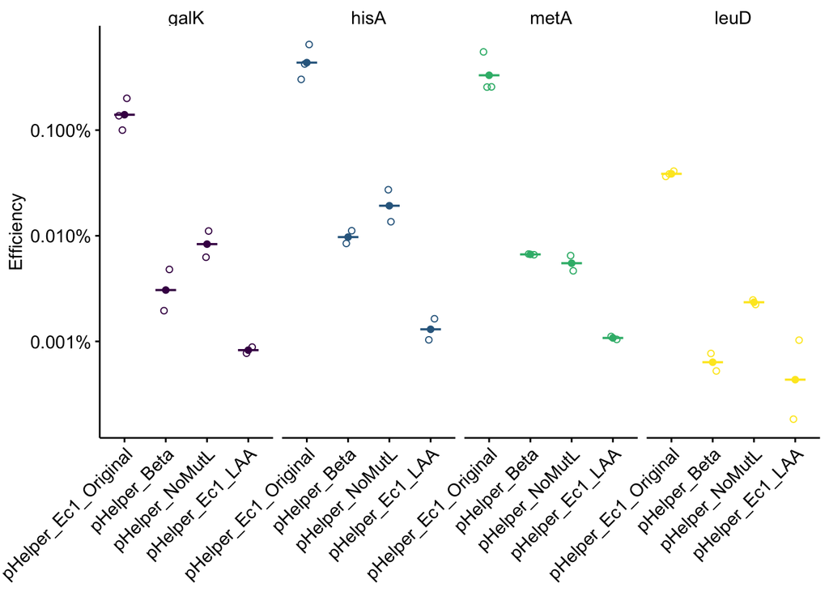

```r
#Calculate negative control values for ORBIT and lambda red
#orbit_bg <- (df_lam_gold %>% filter(locus=='-' & exp == 'ORBIT'))$avg_eff[1]
#lam_bg <-  (df_lam_gold %>% filter(locus=='-' & exp == 'lambda_red'))$avg_eff[1]

#Plot individual datapoints, mean dots and crossbars and negative control X's
plot_eff <- ggplot(df_eff %>% filter(locus!='-'), aes(x = helper_plasmid, y = eff , color = locus)) +
  #geom_point(data = . %>% filter(replicate ==1), aes(y = bg), shape = 4, color= 'light gray')+
  stat_summary(fun = 'mean', geom = 'crossbar',width = 0.5, size = 0.25)+
  stat_summary(fun = 'mean', geom = 'point')+
  geom_point(position = position_jitterdodge(dodge.width = 1, jitter.width = 1), shape = 21) +
  facet_grid(~locus)+
  scale_color_viridis_d()+
  scale_y_log10(labels = scales::label_percent(accuracy = 0.001), breaks = c(0.00001,0.0001, 0.001, 0.01) ) +#
  #scale_x_discrete(labels = c('ORBIT','λRed'))+
  labs(y = 'Efficiency', x = NULL, fill = 'Strand') + guides(color = 'none') +
  theme(axis.text.x = element_text(angle = 45, hjust = 1))


plot_eff
```

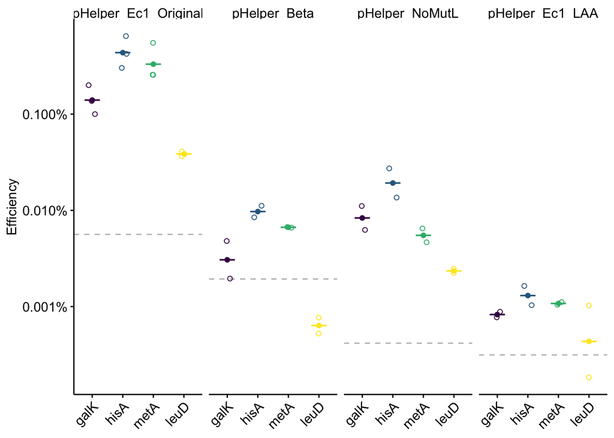

```r
#Plot individual datapoints, mean dots and crossbars and negative control X's

plot_eff_2 <- ggplot(df_eff %>% filter(locus!='-'), aes(x = locus, y = eff , color = locus)) +
  geom_hline(data = df_eff %>% filter(locus == '-' & replicate ==1), aes(yintercept = avg_eff), linetype = 2, color= 'gray')+
  stat_summary(fun = 'mean', geom = 'crossbar',width = 0.5, size = 0.25)+
  stat_summary(fun = 'mean', geom = 'point')+
  geom_point(position = position_jitterdodge(dodge.width = 1, jitter.width = 1), shape = 21) +
  facet_grid(~helper_plasmid)+
  scale_color_viridis_d()+
  scale_y_log10(labels = scales::label_percent(accuracy = 0.001), breaks = c(0.00001,0.0001, 0.001, 0.01) ) +#
  #scale_x_discrete(labels = c('ORBIT','λRed'))+
  labs(y = 'Efficiency', x = NULL, fill = 'Strand') + guides(color = 'none') +
  theme(axis.text.x = element_text(angle = 45, hjust = 1))


plot_eff_2
```

# S5C - pHelper variant background SNPs

```r
df_breseq_1 <-  read_csv("../../data/low_throughput_experiments/2023_breseq_WT_49kb_data.csv")

df_breseq_1
```

```
## # A tibble: 108 × 3
##    locus                 sample mutation
##    <chr>                  <dbl> <chr>
##  1 missing coverage (MC)      1 deletion
##  2 missing coverage (MC)      2 deletion
##  3 missing coverage (MC)      3 deletion
##  4 missing coverage (MC)      4 deletion
##  5 crl                        1 deletion
##  6 crl                        2 deletion
##  7 crl                        3 deletion
##  8 crl                        4 deletion
##  9 b4395                      1 none
## 10 b4395                      2 none
## # … with 98 more rows
```

```r
df_ids <- tibble(sample = 1:4,
                      plasmid = c('WT', 'pHelper_Ec1_Original','pHelper_Ec1_Original','pHelper_Ec1_Original'),
                      deletion = c('none','none','galK_original','134kb'),
                      replicate = 1:4)

df_bre_id_1 <- left_join(df_breseq_1, df_ids, by = 'sample') %>%
  mutate(plasmid = factor(plasmid, levels = c('WT','pHelper_Ec1_Original' )))

df_bre_id_1
```

```
## # A tibble: 108 × 6
##    locus                 sample mutation plasmid              deletion   repli…¹
##    <chr>                  <dbl> <chr>    <fct>                <chr>        <int>
##  1 missing coverage (MC)      1 deletion WT                   none             1
##  2 missing coverage (MC)      2 deletion pHelper_Ec1_Original none             2
##  3 missing coverage (MC)      3 deletion pHelper_Ec1_Original galK_orig…       3
##  4 missing coverage (MC)      4 deletion pHelper_Ec1_Original 134kb            4
##  5 crl                        1 deletion WT                   none             1
##  6 crl                        2 deletion pHelper_Ec1_Original none             2
##  7 crl                        3 deletion pHelper_Ec1_Original galK_orig…       3
##  8 crl                        4 deletion pHelper_Ec1_Original 134kb            4
##  9 b4395                      1 none     WT                   none             1
## 10 b4395                      2 none     pHelper_Ec1_Original none             2
## # … with 98 more rows, and abbreviated variable name ¹replicate
```

```r
df_breseq_2 <- read_csv("../../data/low_throughput_experiments/2023_mut_rate_breseq_summary.csv")

df_breseq_2
```

```
## # A tibble: 300 × 3
##    locus                 sample mutation
##    <chr>                  <dbl> <chr>
##  1 missing coverage (MC)      1 deletion
##  2 missing coverage (MC)      2 deletion
##  3 missing coverage (MC)      3 deletion
##  4 missing coverage (MC)      4 deletion
##  5 missing coverage (MC)      5 deletion
##  6 missing coverage (MC)      6 deletion
##  7 missing coverage (MC)      7 deletion
##  8 missing coverage (MC)      8 deletion
##  9 missing coverage (MC)      9 deletion
## 10 missing coverage (MC)     10 deletion
## # … with 290 more rows
```

```r
df_plasmids <- tibble(sample = 1:12,
                      plasmid = c(rep('pHelper_Beta',3),rep('pHelper_NoMutL',3),rep('pHelper_Ec1_LAA',3),rep('pHelper_Ec1_Original',3)),
                      deletion = rep(c('galK','hisA','metA'),4),
                      replicate = rep(c(1,2,3), 4))

df_bre_id_2 <- left_join(df_breseq_2, df_plasmids, by = 'sample') %>%
  mutate(plasmid = factor(plasmid, levels = c('pHelper_Ec1_Original','pHelper_Beta','pHelper_NoMutL','pHelper_Ec1_LAA' )))

df_bre_plasmid <- bind_rows(df_bre_id_1, df_bre_id_2)

df_bre_plasmid
```

```
## # A tibble: 408 × 6
##    locus                 sample mutation plasmid              deletion   repli…¹
##    <chr>                  <dbl> <chr>    <fct>                <chr>        <dbl>
##  1 missing coverage (MC)      1 deletion WT                   none             1
##  2 missing coverage (MC)      2 deletion pHelper_Ec1_Original none             2
##  3 missing coverage (MC)      3 deletion pHelper_Ec1_Original galK_orig…       3
##  4 missing coverage (MC)      4 deletion pHelper_Ec1_Original 134kb            4
##  5 crl                        1 deletion WT                   none             1
##  6 crl                        2 deletion pHelper_Ec1_Original none             2
##  7 crl                        3 deletion pHelper_Ec1_Original galK_orig…       3
##  8 crl                        4 deletion pHelper_Ec1_Original 134kb            4
##  9 b4395                      1 none     WT                   none             1
## 10 b4395                      2 none     pHelper_Ec1_Original none             2
## # … with 398 more rows, and abbreviated variable name ¹replicate
```

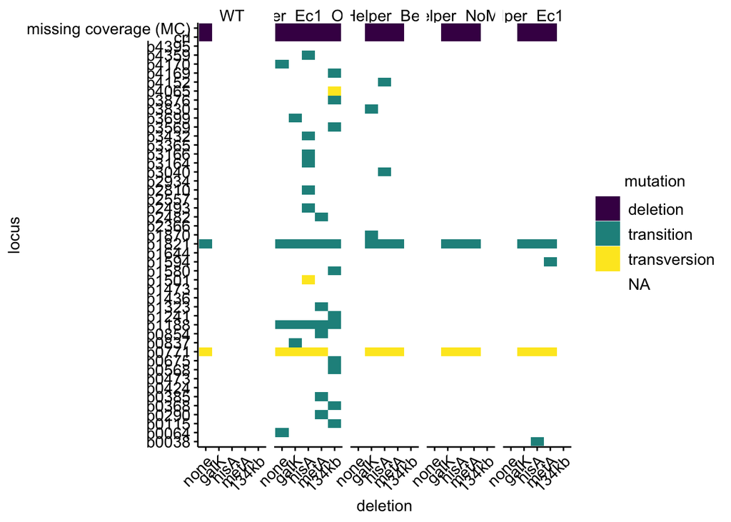

```r
ggplot(df_bre_plasmid %>% mutate(mutation = ifelse(mutation =='none',NA,mutation)) %>% filter(deletion != 'galK_original'), aes(x = deletion, y = locus, fill = mutation)) +
  geom_tile() + facet_grid(~plasmid, scales = 'free') + scale_fill_viridis_d() + theme(axis.text.x = element_text(angle = 45, hjust = 1)) +
  scale_x_discrete(limits = c('none','galK','hisA','metA','134kb'))
```

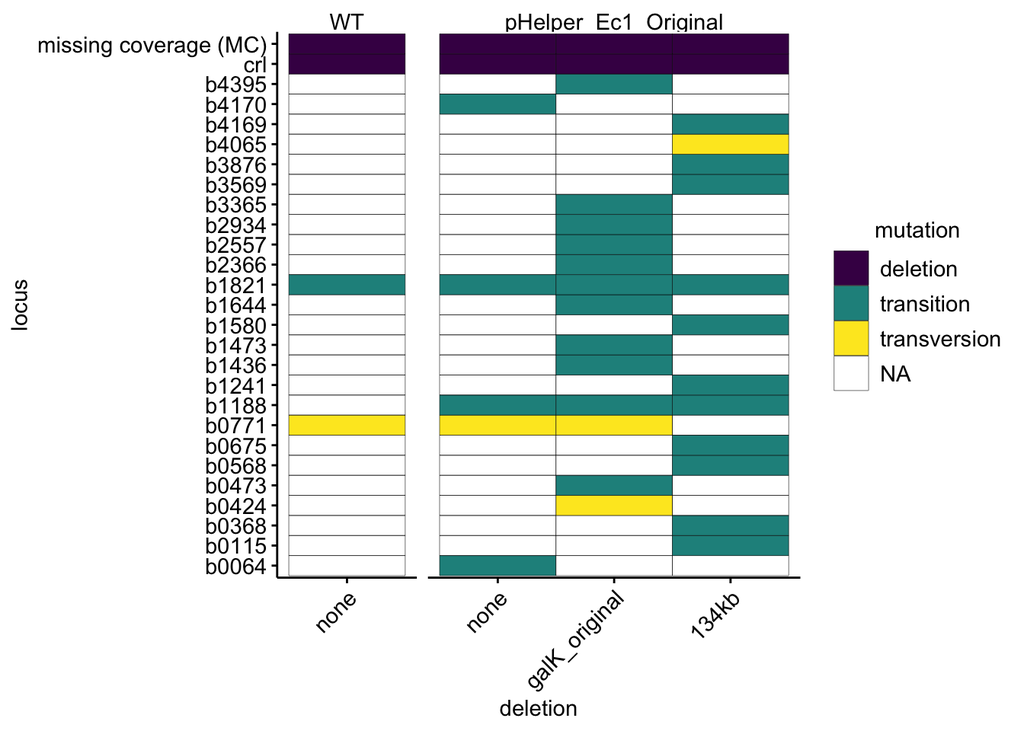

```r
df_bre_id_1 %>%
  mutate(mutation = ifelse(mutation =='none',NA,mutation)) %>%
  mutate(deletion = factor(deletion, levels = c('none','galK_original','134kb'))) %>%
  arrange(locus) %>%
  ggplot(aes(x = deletion, y = locus, fill = mutation)) +
  geom_tile(color = 'black') + facet_grid(~plasmid, scales = 'free',space = 'free_x') + scale_fill_viridis_d() + theme(axis.text.x = element_text(angle = 45, hjust = 1))
```

note in the helper plasmid only strain - b0064 is the araC from the plasmid, which has a single mutation in it. b4170 is mutL, which intentionally has a mutation in it on the plasmid. The two mutants galK original and 134kb both had the helper plasmid cured. You can see that all strains retain the 4 mutations in the WT, except for the 134kb, which lost part of that region due to the large deletion. Note that the helper plasmid stock accumulated a mutation in b1188 which was passed to the other two strains.

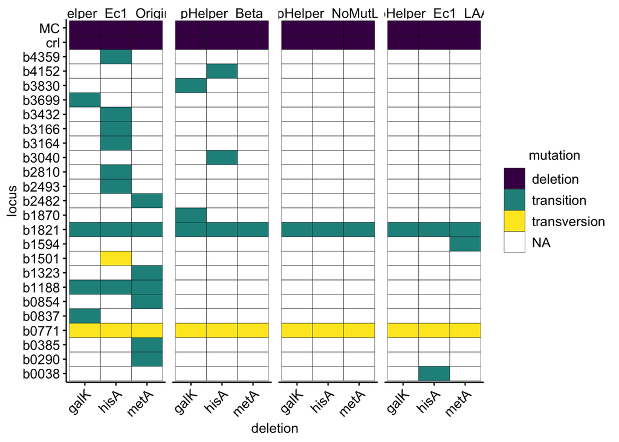

```r
plot_locus_snps <- df_bre_id_2 %>%
  mutate(mutation = ifelse(mutation =='none',NA,mutation)) %>%
  mutate(locus = ifelse(locus == 'missing coverage (MC)', 'MC', locus)) %>%
  #mutate(deletion = factor(deletion, levels = c('none','galK_original','134kb'))) %>%
  arrange(locus) %>%
  ggplot(aes(x = deletion, y = locus, fill = mutation)) +
  geom_tile(color = 'black') + facet_grid(~plasmid, scales = 'free',space = 'free_x') + scale_fill_viridis_d() + theme(axis.text.x = element_text(angle = 45, hjust = 1))

plot_locus_snps
```

# S5D - pHelper variant SNPs summary

```r
df_mut_counts <- df_bre_id_2 %>%
  filter(mutation != 'none') %>%
  group_by(sample, plasmid, replicate)%>%
  summarise(count = n()) %>%
  group_by(plasmid) %>%
  mutate(avg = mean(count))

df_mut_counts
```

```
## # A tibble: 12 × 5
## # Groups:   plasmid [4]
##    sample plasmid              replicate count   avg
##     <dbl> <fct>                    <dbl> <int> <dbl>
##  1      1 pHelper_Beta                 1     6  5.33
##  2      2 pHelper_Beta                 2     6  5.33
##  3      3 pHelper_Beta                 3     4  5.33
##  4      4 pHelper_NoMutL               1     4  4
##  5      5 pHelper_NoMutL               2     4  4
##  6      6 pHelper_NoMutL               3     4  4
##  7      7 pHelper_Ec1_LAA              1     4  4.67
##  8      8 pHelper_Ec1_LAA              2     5  4.67
##  9      9 pHelper_Ec1_LAA              3     5  4.67
## 10     10 pHelper_Ec1_Original         1     7  9.67
## 11     11 pHelper_Ec1_Original         2    12  9.67
## 12     12 pHelper_Ec1_Original         3    10  9.67
```

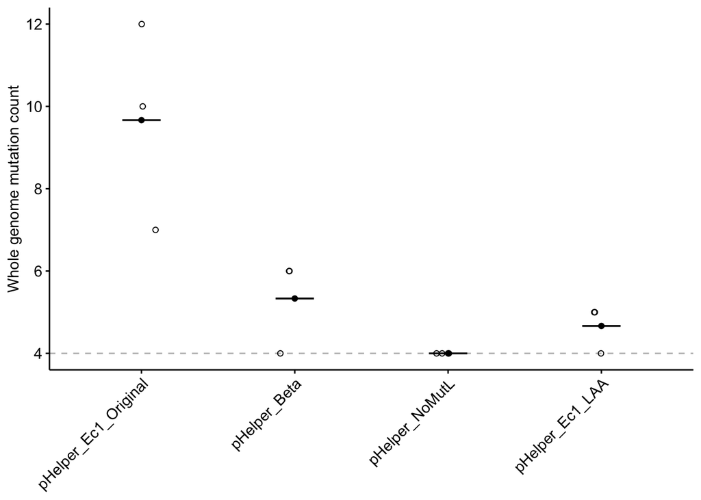

```r
plot_muts <- ggplot(df_mut_counts, aes(x = plasmid, y = count)) +
  geom_hline(yintercept = 4, linetype =2, color = 'gray')+
  stat_summary(fun = 'mean', geom = 'crossbar',width = 0.25, size = 0.25)+
  stat_summary(fun = 'mean', geom = 'point')+
  geom_jitter(width = 0.1, height = 0, shape =21) +
  labs(x = NULL, y = "Whole genome mutation count")+
  theme(axis.text.x = element_text(angle = 45, hjust = 1))

plot_muts
```

# S5E - pHelper_V2 efficiencies

```r
df_fixed <- read_csv("../../data/low_throughput_experiments/2023_06_06_mutation_rate_fixed_pHelper_eff.csv") %>% #read in csv
  mutate(eff = Kan_count / LB_count) %>% group_by(helper_plasmid, locus) %>% mutate(avg_eff = mean(eff)) #%>% #calculate efficiency and average efficiency for replicates")
  #mutate(helper_plasmid = factor(helper_plasmid, levels = c('pHelper_Ec1_original','pHelper_Ec1_fixed','pHelper_Ec1_noMutL_fixed' ))) %>%
  #mutate(locus = factor(locus, levels = c('galK','hisA','metA','leuD','pInt_only')))

df_temp <- read_csv("../../data/low_throughput_experiments/2023_12_14_pHelperV2TSamp_goldstd.csv") %>%
  mutate(eff = Kan / LB) %>%
  group_by(locus) %>% mutate(avg_eff = mean(eff, na.rm = T)) %>%  #calculate efficiency and average efficiency for replicates
  mutate(helper_plasmid = 'pHelper_V2_TS_ampR')


df_all <- bind_rows(df_fixed, df_temp) %>%
    mutate(helper_plasmid = factor(helper_plasmid, levels = c('pHelper_Ec1_original','pHelper_Ec1_fixed','pHelper_Ec1_noMutL_fixed', 'pHelper_V2_TS_ampR'))) %>%
    mutate(locus = factor(locus, levels =c('galK','hisA','metA','leuD','pInt_only')))
```

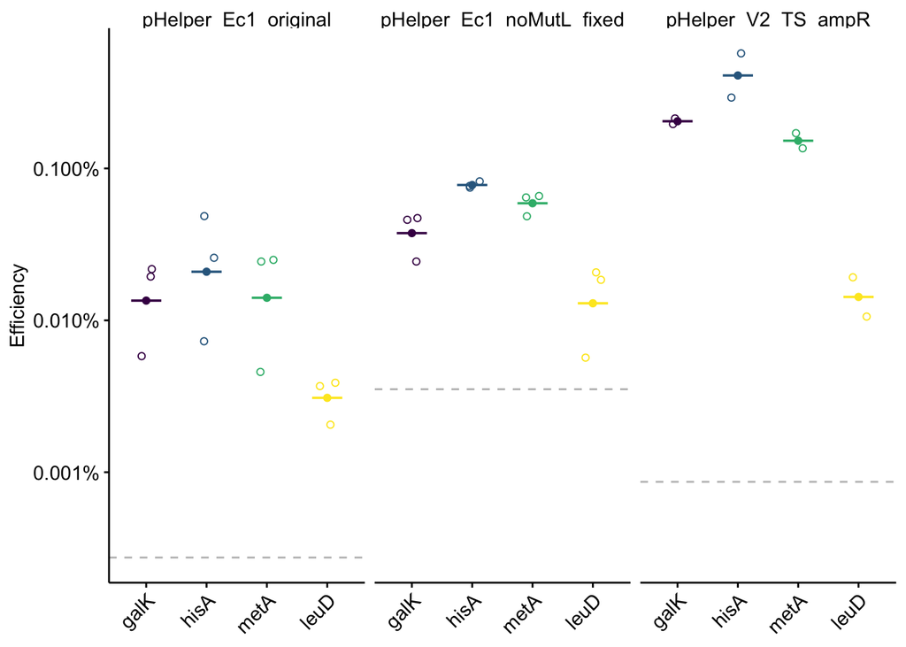

```r
#Plot individual datapoints, mean dots and crossbars and negative control X's

plot_fixed_eff <- ggplot(df_all %>% filter(locus!='pInt_only') %>% filter(helper_plasmid !='pHelper_Ec1_fixed'), aes(x = locus, y = eff , color = locus)) +
  geom_hline(data = df_all %>% filter(locus == 'pInt_only' & replicate ==1)%>% filter(helper_plasmid !='pHelper_Ec1_fixed'), aes(yintercept = avg_eff), linetype = 2, color= 'gray')+
  #geom_hline(data = df_fixed %>% filter(locus == 'pInt_only'), aes(yintercept = eff), linetype = 2, color= 'gray')+
  stat_summary(fun = 'mean', geom = 'crossbar',width = 0.5, size = 0.25)+
  stat_summary(fun = 'mean', geom = 'point')+
  geom_point(position = position_jitterdodge(dodge.width = 1, jitter.width = 1), shape = 21) +
  facet_grid(~helper_plasmid)+
  scale_color_viridis_d()+
  scale_y_log10(labels = scales::label_percent(accuracy = 0.001), breaks = c(0.00001,0.0001, 0.001, 0.01) ) +#
  #scale_x_discrete(labels = c('ORBIT','λRed'))+
  labs(y = 'Efficiency', x = NULL, fill = 'Strand') + guides(color = 'none') +
  theme(axis.text.x = element_text(angle = 45, hjust = 1))

plot_fixed_eff
```

# S5G - pHelper_TS_V2_ampR curing rate

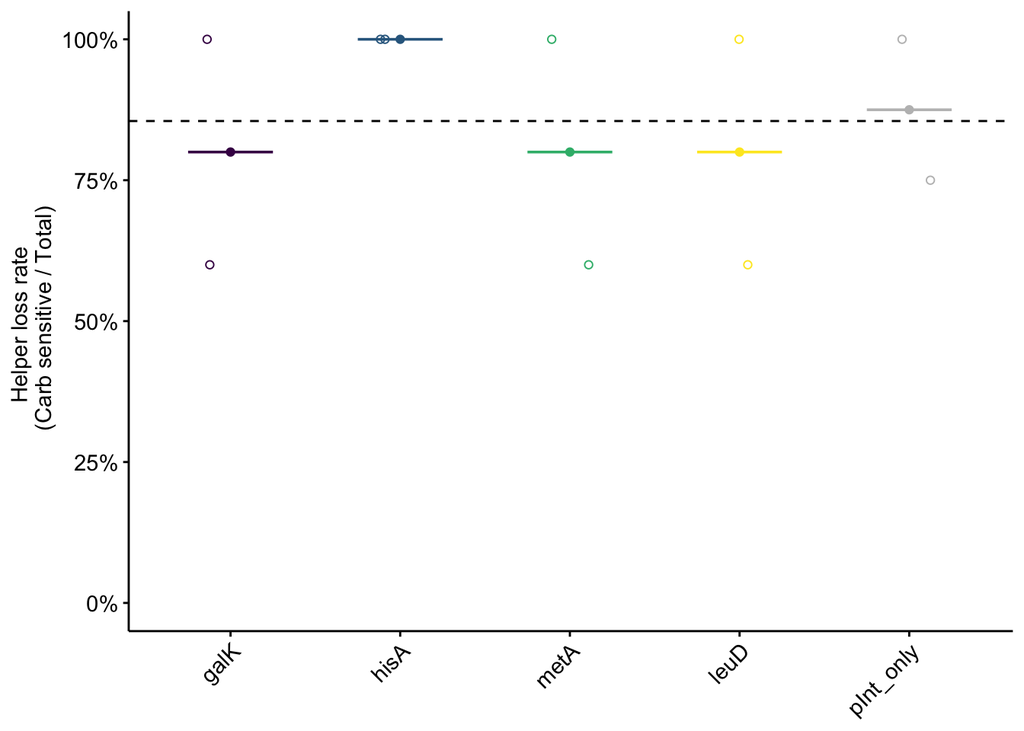

```r
df_loss <- read_csv("../../data/low_throughput_experiments/2023_12_14_pHelperV2TSamp_loss_rate.csv") %>%
  mutate(not_lost = Carb / LB) %>%
  mutate(loss_rate = 1-not_lost) %>%
  group_by(locus) %>% mutate(avg_eff = mean(loss_rate, na.rm = T)) %>%  #calculate efficiency and average efficiency for replicates
  mutate(locus = factor(locus, levels =c('galK','hisA','metA','leuD','pInt_only')))

loss_rate_avg <- mean(df_loss$loss_rate)

plot_loss <- ggplot(df_loss, aes(x = locus, y = loss_rate , color = locus)) +
  geom_hline(yintercept = loss_rate_avg, linetype = 2, color = 'black')+
  stat_summary(fun = 'mean', geom = 'crossbar',width = 0.5, size = 0.25)+
  stat_summary(fun = 'mean', geom = 'point')+
  geom_point(position = position_jitterdodge(dodge.width = 1, jitter.width = 1), shape = 21) +
  #facet_grid(~locus)+
  #scale_color_viridis_d()+
  scale_color_manual( values = c("#440154FF", "#31688EFF", "#35B779FF" ,"#FDE725FF","gray"))+
  scale_y_continuous(labels = scales::label_percent(), limits = c(0, NA)) +
  #scale_y_log10(labels = scales::label_percent(accuracy = 0.0001), limits = c(0.0000075, 0.01)) +
  labs(y = 'Helper loss rate \n (Carb sensitive / Total)', x = NULL) + guides(color = 'none') +
  theme(axis.text.x = element_text(angle = 45, hjust = 1))

plot_loss
```

# Create figure

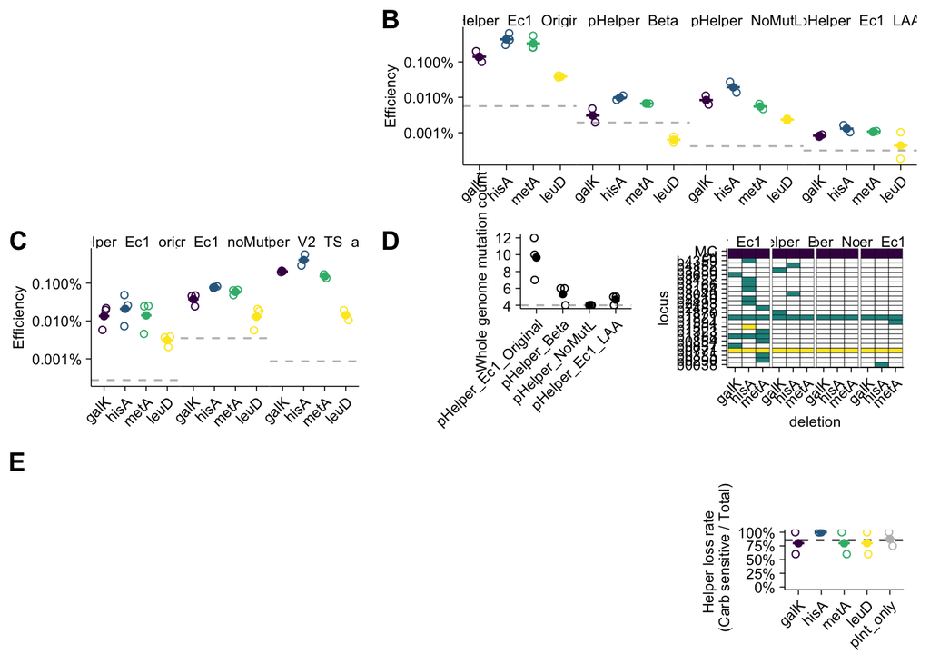

```r
theme_set(theme_figure())


subfig1 <- plot_grid(plot_muts,  plot_locus_snps + guides(fill = 'none'), ncol = 2, rel_widths = c(2,3))
subfig2 <- plot_grid(NULL, NULL, NULL, plot_loss, ncol = 2, nrow = 2, rel_widths = c(1,1), rel_heights = c(1, 2))

fig_mut_vars <- plot_grid(NULL,plot_eff_2,plot_fixed_eff, subfig1, NULL, subfig2, ncol = 2,rel_widths = c(2,3),
                   align = 'hv', axis = 'lr', scale = 1,
                   labels = c('','B','C','D','E',''))


fig_mut_vars
```

```r
save_plot("../../figures/r_pdf_figs/supp_figs/supp_mut_rate_vars.pdf", fig_mut_vars, base_width = 8, base_height = 9)
```

```